# Community detection for 3vs 1 organoid data

Tianyi Chen

2025-03-17

## https://tianyichen97.github.io/Organoid/3VS1/pre.html

### Q: whether there is number of communities difference between single organoid(M07914) and multiple organoid(M07915)?

## Basic information.

The file name(ex:‘/cis/project/organoid/Dec_29_2024_ecr_results/M07915/Stimulation/000295/data.raw_20241213_18h15m.pkl), with ’M07914’ or ‘M07915’, indicates single organoid placed on the MEA or multiple organoids. Each file contains recording from 6 wells. And things like “000298” in the filenames indicates its stage/time. Details shown below. **Warning, the stage is a concept by me that has not been confirmed by the scientists.** Each file’s each well we have a directed graph. Stored in the format of edge list. There are in total 12 files , thus we should have 72 graphs in total, after eliminating the wells in some files that have 0 edges, we have 60 graphs in total to be analyzed.

Below are detailed info about what filename indicates:

### More info

———Below are copied from Dowlette’s document:

241018: this is the date the experiment was conducted

–M07914 (Single organoid plate number)

ActivityScan (Finding the electrodes that are active)

```
000297 (folder where the h5 file is located)
```

Network (Recording from the active electrodes)

```
000298 (folder where the baseline (before all stim) h5 file is located)
000300 (folder where the recording after stimulation #1(random location of stim electrodes) h5 file is located)
000302 (folder where the recording after stimulation #2(single region location of stim electrodes) h5 file is located)
```

Stimulation (Recording from the stimulation)

```
000299 (folder where data from during stimulation #1 (random location of stim electrodes) h5 file is located)
000301 (folder where data from during stimulation #2 (single region location of stim electrodes) h5 file is located)
```

–M07915 (Multi organoid plate number)

ActivityScan (Finding the electrodes that are active)

```
000289 (folder where the h5 file is located)
```

Network (Recording from the active electrodes)

```
000290 (folder where the baseline (before all stim) h5 file is located)
000293 (folder where the recording after stimulation #1(random location of stim electrodes) h5 file is located)
000296 (folder where the recording after stimulation #2(single region location of stim electrodes) h5 file is located)
```

Stimulation (Recording from the stimulation)

```
000291 (folder where data from during stimulation #1 (random location of stim electrodes) h5 file is located)
000295 (folder where data from during stimulation #2 (single region location of stim electrodes) h5 file is located)
```

```r
## Functions

library('randnet')
library(irlba)
library(mclust)
library(igraph)
library(ggplot2)
library(MASS)
library(mvtnorm)

plot_GMM_contours <- function(kk) {

  mc = summary_table$GMM[kk][[1]]$mc

  # Extract GMM model results
  clusters <- mc$classification  # Cluster labels
  Xhat <- mc$data[,1:2]  # Use first two dimensions for visualization

  # Create a data frame for plotting
  plot_data <- data.frame(
    X1 = Xhat[,1],
    X2 = Xhat[,2],
    Cluster = as.factor(clusters)
  )

  # Generate contour data for each cluster using estimated parameters
  contour_data <- data.frame()

  for (k in 1:mc$G) {
    mean_k <- mc$parameters$mean[, k]  # Mean of cluster k
    sigma_k <- mc$parameters$variance$sigma[,,k]  # Covariance matrix of cluster k

    # Create a grid for density estimation
    x_seq <- seq(min(Xhat[,1]), max(Xhat[,1]), length.out = 100)
    y_seq <- seq(min(Xhat[,2]), max(Xhat[,2]), length.out = 100)
    grid <- expand.grid(X1 = x_seq, X2 = y_seq)

    # Compute multivariate density on the grid
    density_values <- dmvnorm(grid, mean = mean_k, sigma = sigma_k)
    grid$Density <- density_values
    grid$Cluster <- as.factor(k)

    contour_data <- rbind(contour_data, grid)
  }

  # Plot scatter with GMM contours
  ggplot(plot_data, aes(x = X1, y = X2, color = Cluster)) +
    geom_point(size = 3, alpha = 0.7) +  # Scatter plot of ASE embeddings
    geom_contour(data = contour_data, aes(x = X1, y = X2, z = Density, color = Cluster), bins = 5) +  # GMM contour lines
    labs(title =  paste( summary_table$Well[kk] ,summary_table$Group[kk] , 'Stage' , summary_table$Stage[kk]),
         x = "ASE Dimension 1",
         y = "ASE Dimension 2") +
    theme_minimal() +
    scale_color_brewer(palette = "Set1")
}
full.ase <- function(A, d, diagaug=TRUE, doptr=FALSE) {
  require(RSpectra)

  # doptr
  if (doptr) {
    g <- ptr(A)
    A <- g[]
  } else {
    A <- A[]
  }

  # diagaug
  if (diagaug) {
    diag(A) <- rowSums(A) / (nrow(A)-1)
  }

  A.svd <- svds(A,k=d)
  Xhat <- A.svd$u %*% diag(sqrt(A.svd$d))
  Xhat.R <- NULL

  if (!isSymmetric(A)) {
    Xhat.R <- A.svd$v %*% diag(sqrt(A.svd$d))
  }

  return(list(eval=A.svd$d, Xhat=Matrix(Xhat), Xhat.R=Xhat.R))
}
getElbows <- function(dat, n = 3, threshold = FALSE, plot = TRUE, main="") {
  if (is.matrix(dat)) {
    d <- sort(apply(dat,2,sd), decreasing=TRUE)
  } else {
    d <- sort(dat,decreasing=TRUE)
  }

  if (!is.logical(threshold))
    d <- d[d > threshold]

  p <- length(d)
  if (p == 0)
    stop(paste("d must have elements that are larger than the threshold ",
               threshold), "!", sep="")

  lq <- rep(0.0, p)                     # log likelihood, function of q
  for (q in 1:p) {
    mu1 <- mean(d[1:q])
    mu2 <- mean(d[-(1:q)])              # = NaN when q = p
    sigma2 <- (sum((d[1:q] - mu1)^2) + sum((d[-(1:q)] - mu2)^2)) /
      (p - 1 - (q < p))
    lq[q] <- sum( dnorm(  d[1:q ], mu1, sqrt(sigma2), log=TRUE) ) +
      sum( dnorm(d[-(1:q)], mu2, sqrt(sigma2), log=TRUE) )
  }

  q <- which.max(lq)
  if (n > 1 && q < (p-1)) {
    q <- c(q, q + getElbows(d[(q+1):p], n-1, plot=FALSE))
  }

  if (plot==TRUE) {
    if (is.matrix(dat)) {
      sdv <- d # apply(dat,2,sd)
      plot(sdv,type="b",xlab="dim",ylab="stdev",main=main)
      points(q,sdv[q],col=2,pch=19)
    } else {
      plot(dat, type="b",main=main)
      points(q,dat[q],col=2,pch=19)
    }
  }

  return(q)
}
doMclustASE_directed = function(g, dmax=100) {
  #pacman::p_load(irlba, gmmase, mclust)
  n = vcount(g)
  Kmax = n/5
  ase = full.ase(g, d=dmax, diagaug=TRUE, doptr=FALSE)
  elb = getElbows(ase$eval, plot=F)
  #dhat = max(elb[1],2)
  dhat = elb[1]
  Xhat = cbind(ase$Xhat[,1:dhat],ase$Xhat.R[,1:dhat])
  #Xhat = ase$Xhat[,1:dhat]
  mc = Mclust(Xhat, G=2:Kmax, verbose=T)
  Khat = mc$G
  return( list(mc=mc,Khat=Khat) )
}

stage1 <- c('000297', '000289')
stage2 <- c('000298', '000290')
stage3 <- c('000300', '000293')
stage4 <- c('000302', '000296')
stage5 <- c('000299', '000291')
stage6 <- c('000301', '000295')

get_stage <- function(file_path) {
  if (grepl(paste(stage1, collapse = "|"), file_path)) {
    return(1)
  } else if (grepl(paste(stage2, collapse = "|"), file_path)) {
    return(2)
  } else if (grepl(paste(stage3, collapse = "|"), file_path)) {
    return(3)
  } else if (grepl(paste(stage4, collapse = "|"), file_path)) {
    return(4)
  } else if (grepl(paste(stage5, collapse = "|"), file_path)) {
    return(5)
  } else if (grepl(paste(stage6, collapse = "|"), file_path)) {
    return(6)
  } else {
    return(NA) # Assign NA if no stage matches
  }
}

scree_plot_tc <- function(kk){

  file = summary_table$File[kk]
  well = summary_table$Well[kk]

  subset_data <- subset(edge_list, File == file & Well == well)

  if (nrow(subset_data) == 0) {
    next
  }

  n_rows <-   n_cols   <- unique(subset_data$dim)

  # Create a sparse adjacency matrix
  sparse_matrix <- sparseMatrix(
    i = subset_data$Row + 1,
    j = subset_data$Column + 1,
    dims = c(n_rows, n_cols)
  )

  g <- graph_from_adjacency_matrix(sparse_matrix, weighted = NULL, mode = "directed", diag = FALSE)

  components <- igraph::clusters(g, mode="weak")
  biggest_cluster_id <- which.max(components$csize)
  vert_ids <- V(g)[components$membership == biggest_cluster_id]
  g <- igraph::induced_subgraph(g, vert_ids)

  dmax = 100

  ase = full.ase(g, d=dmax, diagaug=TRUE, doptr=FALSE)

  elb = getElbows(ase$eval, plot=T, main = paste('Scree plot for', summary_table$Group[kk] , 'Stage' , summary_table$Stage[kk]) )

}
```

## Data processing and the summary table

Below we show the summary table which contains filename, well, stage, group(M07914 or M07915), number of nodes, num of edges and GMM+BIC results for communitiy detection and BHMC results.

Note the num of nodes and num of edges showing in the table is for the induced graph from largest weakly connected component for directed graph. And this is a big deal, if not doing so, the EM algorithm will take forever to run.

Recall – A digraph is strongly connected if for every pair of distinct vertices u and v there exists a directed path from u and v. Note this requires path from bot hu to v and v to u.

– A digraph is weakly connected if when considering it as an undirected graph it is connected. I.e., for every pair of distinct vertices u and v there exists an undirected path (potentially running opposite the direction on an edge) from u to v. This only requires there is a direction either from u to v or v to u.

```r
rerun <- F
# Define the filename for saving results
summary_file <- "summary_table.RData"

if (rerun) {
  cat("Starting the long processing...\n")
    edge_list = read.csv('/Users/tianyichen/Desktop/Research/PhDresearch/Hopkins_Organoid/Codes/R/adjacency_edges.csv')
    filenames = unique(edge_list$File)

    # Initialize a data frame to store the summary
    summary_table <- data.frame(
      File = character(),
      Well = character(),
      Num_edges = character(),
      Num_nodes = character(),
      Num_Communities_BHMC = character(),
      Num_Communities_ASE_GMM = character(),
      GMM = I(list()),
      stringsAsFactors = FALSE
    )


    for (file in filenames) {
      for (well in c("well000", "well001", "well002", "well003", "well004", "well005")) {
        subset_data <- subset(edge_list, File == file & Well == well)

        if (nrow(subset_data) == 0) {
          next
        }

        n_rows <-   n_cols   <- unique(subset_data$dim)

        # Create a sparse adjacency matrix
        sparse_matrix <- sparseMatrix(
          i = subset_data$Row + 1,
          j = subset_data$Column + 1,
          dims = c(n_rows, n_cols)
        )

        g <- graph_from_adjacency_matrix(sparse_matrix, weighted = NULL, mode = "directed", diag = FALSE)

        components <- igraph::clusters(g, mode="weak")
        biggest_cluster_id <- which.max(components$csize)
        vert_ids <- V(g)[components$membership == biggest_cluster_id]
        g <- igraph::induced_subgraph(g, vert_ids)

        n = vcount(g)
        num_edges = ecount(g)

        if ( n  < 100 ) {
          # Add a row to the summary table with NULL communities
          summary_table <- rbind(summary_table, data.frame(
            File = file,
            Well = well,
            Num_edges = num_edges,
            Num_nodes = n,
            Num_Communities_BHMC = NA,
            Num_Communities_ASE_GMM = NA,
            GMM = I(list(NA))
          ))
          next
        }


        bhmc <- tryCatch({
          #print(c(file,well))
          as.numeric(BHMC.estimate(g[], n/5 )$K)[1]
        }, error = function(e) {
          NA
        })

        CEPYP <- tryCatch({
          GMM_result = doMclustASE_directed(g, dmax = 10)

          # Extract Khat safely
          if (is.list(GMM_result) && "Khat" %in% names(GMM_result)) {
            as.numeric(GMM_result$Khat)[1]
          } else {
            stop("GMM_result does not contain Khat")
          }
        }, error = function(e) {
          cat("Error in GMM clustering:", e$message, "\n")
          return(NA)
        })


        summary_table <- rbind(summary_table, data.frame(
          File = file,
          Well = well,
          Num_edges = num_edges,
          Num_nodes = n,
          Num_Communities_BHMC = bhmc,
          Num_Communities_ASE_GMM = CEPYP,
          GMM = I(list(GMM_result)))
        )
      }
    }

    summary_table$Group <- ifelse(grepl("M07914", summary_table$File), "M07914",
                                  ifelse(grepl("M07915", summary_table$File), "M07915", NA))
    summary_table$Stage <- sapply(summary_table$File, get_stage)

  # Save the summary table to the current directory
  save(summary_table, file = summary_file)
  cat("Summary table saved to", summary_file, "\n")

} else {
  cat("Skipping the data processing.\n")
  # Load previously saved summary table (if available)
  if (file.exists(summary_file)) {
    load(summary_file, envir = .GlobalEnv)
    cat("Loaded previous summary table from", summary_file, "\n")
  } else {
    cat("No previous summary table found.\n")
  }
}
```

```
## Skipping the data processing.
## Loaded previous summary table from summary_table.RData
```

```r
# Display the summary table
head(summary_table)
```

```
##                                                                                                   File
## 1 /cis/project/organoid/Dec_29_2024_ecr_results/M07915/Stimulation/000295/data.raw_20241213_18h15m.pkl
## 2 /cis/project/organoid/Dec_29_2024_ecr_results/M07915/Stimulation/000295/data.raw_20241213_18h15m.pkl
## 3 /cis/project/organoid/Dec_29_2024_ecr_results/M07915/Stimulation/000295/data.raw_20241213_18h15m.pkl
## 4 /cis/project/organoid/Dec_29_2024_ecr_results/M07915/Stimulation/000295/data.raw_20241213_18h15m.pkl
## 5 /cis/project/organoid/Dec_29_2024_ecr_results/M07915/Stimulation/000295/data.raw_20241213_18h15m.pkl
## 6 /cis/project/organoid/Dec_29_2024_ecr_results/M07915/Stimulation/000291/data.raw_20241213_18h15m.pkl
##      Well Num_edges Num_nodes Num_Communities_BHMC Num_Communities_ASE_GMM
## 1 well000     45074       847                   20                       6
## 2 well001     14973       871                   29                       3
## 3 well003      5372       468                    5                      13
## 4 well004     11299       409                    5                      10
## 5 well005     11354       649                   20                     108
## 6 well000       595       263                   16                      27
##            GMM  Group Stage
## 1 list(cal.... M07915     6
## 2 list(cal.... M07915     6
## 3 list(cal.... M07915     6
## 4 list(cal.... M07915     6
## 5 list(cal.... M07915     6
## 6 list(cal.... M07915     5
```

## Show embedding of two examples

I arbitrarily choose two graphs that have relatively big LCC, both from stage6, and one from M07914, the other from M07915. I show their scree plot(with singular values) and ASE embedding.

```r
print(summary_table[c(2,33),])
```

```
##                                                                                                    File
## 2  /cis/project/organoid/Dec_29_2024_ecr_results/M07915/Stimulation/000295/data.raw_20241213_18h15m.pkl
## 33 /cis/project/organoid/Dec_29_2024_ecr_results/M07914/Stimulation/000301/data.raw_20241213_18h15m.pkl
##       Well Num_edges Num_nodes Num_Communities_BHMC Num_Communities_ASE_GMM
## 2  well001     14973       871                   29                       3
## 33 well004     53655       973                   21                      11
##             GMM  Group Stage
## 2  list(cal.... M07915     6
## 33 list(cal.... M07914     6
```

### Scree plot

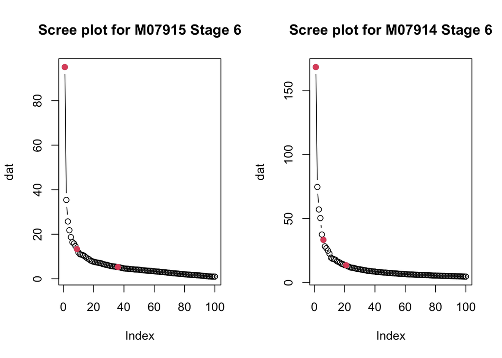

**Figure 1: Scree plot for two chosen directed graphs, both from stage 6, one from M07914 and the other from M07915. Both has the first elbow at d=1.**

```r
edge_list = read.csv('/Users/tianyichen/Desktop/Research /PhDresearch/Hopkins_Organoid/Codes/R/adjacency_edges.csv')
par(mfrow=c(1,2))
scree_plot_tc(2)
scree_plot_tc(33)
```

Due to this is directed graph, with d=1, we have both first left singular vector and first right singular vector, this is why ASE is showing 2 dim.

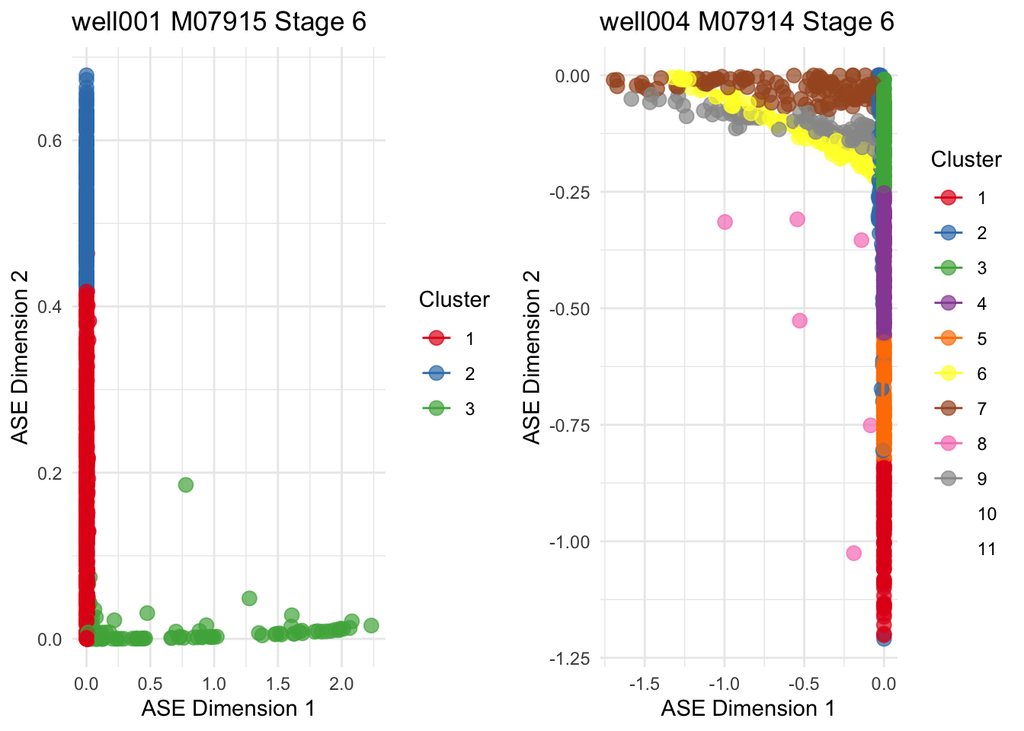

**Figure 2: Dots are ASE embedding colored by there community memebership from running Mclust with number of communities chosen by BIC. Clearly ASE embedding shows the eigenspoke.**

Since there is eigenspoke, can we still trust the below results?

## Number of community analysis:

### overall result

Mean and median for two groups with two methods:ASE and GMM and BHMC. M07915 has higher overall mean and median compared to M07914.

```r
filtered_table <- subset(summary_table, !is.na(Num_Communities_BHMC) & !is.na(Group))

group_1 <- subset(filtered_table, Group == "M07914")
group_2 <- subset(filtered_table, Group == "M07915")


#Single organoid plate – M07914
#Multi-organoid plate – M07915

group_1_mean <- mean(group_1$Num_Communities_BHMC)
group_2_mean <- mean(group_2$Num_Communities_BHMC)

group_1_median <- median(group_1$Num_Communities_BHMC)
group_2_median <- median(group_2$Num_Communities_BHMC)


cat("Group M07914 BHMC: Mean =", group_1_mean, ", Median BHMC=", group_1_median, "\n")
```

```
## Group M07914 BHMC: Mean = 5.857143 , Median BHMC= 4
```

```r
cat("Group M07915 BHMC: Mean =", group_2_mean, ", Median BHMC=", group_2_median, "\n")
```

```
## Group M07915 BHMC: Mean = 10.14286 , Median BHMC= 6
```

```r
group_1_mean <- mean(group_1$Num_Communities_ASE_GMM)
group_2_mean <- mean(group_2$Num_Communities_ASE_GMM)

group_1_median <- median(group_1$Num_Communities_ASE_GMM)
group_2_median <- median(group_2$Num_Communities_ASE_GMM)


cat("Group M07914 ASE GMM Mean =", group_1_mean, ", Median ASE GMM = ", group_1_median, "\n")
```

```
## Group M07914 ASE GMM Mean = 8.857143 , Median ASE GMM =  5
```

```r
cat("Group M07915 ASE GMM Mean =", group_2_mean, ", Median ASE GMM = ", group_2_median, "\n")
```

```
## Group M07915 ASE GMM Mean = 18.35714 , Median ASE GMM =  8
```

```r
wilcox.test(group_1$Num_Communities_BHMC, group_2$Num_Communities_BHMC)
```

```
##
##  Wilcoxon rank sum test with continuity correction
##
## data:  group_1$Num_Communities_BHMC and group_2$Num_Communities_BHMC
## W = 93.5, p-value = 0.07133
## alternative hypothesis: true location shift is not equal to 0
```

```r
wilcox.test(group_1$Num_Communities_ASE_GMM, group_2$Num_Communities_ASE_GMM)
```

```
##
##  Wilcoxon rank sum test with continuity correction
##
## data:  group_1$Num_Communities_ASE_GMM and group_2$Num_Communities_ASE_GMM
## W = 114.5, p-value = 0.2773
## alternative hypothesis: true location shift is not equal to 0
```

However, no significant difference between two distributions of number of communities by Wilcox test. This is not necessarily bad news!

Further we compare number of communities between M0914 and M0915 for each stage.

```r
library(dplyr)

# Group by 'Group' and 'Stage' and compute mean and count of non-NA values
summary_table_grouped_ASE_GMM <- summary_table %>%
  group_by(Group, Stage) %>%
  summarise(
    max_NUM_communities = max(Num_Communities_ASE_GMM, na.rm = TRUE),
    median_NUM_communities = median(Num_Communities_ASE_GMM, na.rm = TRUE),
    mean_NUM_communities = mean(Num_Communities_ASE_GMM, na.rm = TRUE),
    num_nonNA = sum(!is.na(Num_Communities_ASE_GMM))
    , .groups = "drop")  # Removes unnecessary grouping

# View the result
print(summary_table_grouped_ASE_GMM)
```

```
## # A tibble: 12 × 6
##    Group  Stage max_NUM_communities median_NUM_communities mean_NUM_co…¹ num_n…²
##    <chr>  <dbl>               <dbl>                  <dbl>         <dbl>   <int>
##  1 M07914     1                -Inf                   NA           NaN         0
##  2 M07914     2                  11                    5             5.4       5
##  3 M07914     3                  11                    4             5         6
##  4 M07914     4                  10                    5             6         4
##  5 M07914     5                  12                    8             8         4
##  6 M07914     6                  62                   36.5          36.5       2
##  7 M07915     1                -Inf                   NA           NaN         0
##  8 M07915     2                   5                    3.5           3.5       2
##  9 M07915     3                   4                    4             4         1
## 10 M07915     4                   5                    5             5         1
## 11 M07915     5                  40                   20            20.2       5
## 12 M07915     6                 108                   10            28         5
## # … with abbreviated variable names ¹mean_NUM_communities, ²num_nonNA
```

```r
summary_table_grouped_BHMC <- summary_table %>%
  group_by(Group, Stage) %>%
  summarise(
    max_NUM_communities = max(Num_Communities_BHMC, na.rm = TRUE),
    median_NUM_communities = median(Num_Communities_BHMC, na.rm = TRUE),
    mean_NUM_communities = mean(Num_Communities_BHMC, na.rm = TRUE),
    num_nonNA = sum(!is.na(Num_Communities_BHMC))
    , .groups = "drop")
# View the result
print(summary_table_grouped_BHMC)
```

```
## # A tibble: 12 × 6
##    Group  Stage max_NUM_communities median_NUM_communities mean_NUM_co…¹ num_n…²
##    <chr>  <dbl>               <dbl>                  <dbl>         <dbl>   <int>
##  1 M07914     1                -Inf                   NA          NaN          0
##  2 M07914     2                   4                    1            2          5
##  3 M07914     3                   4                    2            2.33       6
##  4 M07914     4                   5                    2.5          2.75       4
##  5 M07914     5                  19                   12           11.8        4
##  6 M07914     6                  21                   20.5         20.5        2
##  7 M07915     1                -Inf                   NA          NaN          0
##  8 M07915     2                   2                    1.5          1.5        2
##  9 M07915     3                   2                    2            2          1
## 10 M07915     4                   2                    2            2          1
## 11 M07915     5                  19                   10           11.2        5
## 12 M07915     6                  29                   20           15.8        5
## # … with abbreviated variable names ¹mean_NUM_communities, ²num_nonNA
```

Results with BHMC is similar to the ASE and GMM+BIC.